# Machine Learning Prediction Project

Yue Liu

## Summary

Devices such as Jawbone Up, Nike FuelBand, and Fitbit are now possible to collect a large amount of data about personal activity relatively inexpensively. However, People regularly do is quantify how much of their daily exercise rather than how well they do it.

This report is based on training data and we will use testing data to validate our model for prediction performance.Random forest will be undertaken for this project.

## Data Cleaning

```r
# Load necessary R packages
library(rpart)
library(caret)
library(rattle)
library(randomForest)
```

```r
library(rpart.plot)

# Load traning and testing data
Train_data <- read.csv("pml-training.csv", header = TRUE)
Test_data <- read.csv("pml-testing.csv", header = TRUE)

# Investigate Dependent Variable and Training Sample
str(Train_data)
```

```
## 'data.frame':    19622 obs. of  160 variables:
##  $ X                       : int  1 2 3 4 5 6 7 8 9 10 ...
##  $ user_name               : Factor w/ 6 levels "adelmo","carlitos",..: 2 2 2 2 2 2 2 2 2 2 ...
##  $ raw_timestamp_part_1    : int  1323084231 1323084231 1323084231 1323084232 1323084232 1323084232 1323084232 1323084232 1323084232 1323084232 ...
##  $ raw_timestamp_part_2    : int  788290 808298 820366 120339 196328 304277 368296 440390 484323 484434 ...
##  $ cvtd_timestamp          : Factor w/ 20 levels "02/12/2011 13:32",..: 9 9 9 9 9 9 9 9 9 9 ...
##  $ new_window              : Factor w/ 2 levels "no","yes": 1 1 1 1 1 1 1 1 1 1 ...
##  $ num_window              : int  11 11 11 12 12 12 12 12 12 12 ...
##  $ roll_belt               : num  1.41 1.41 1.42 1.48 1.48 1.45 1.42 1.42 1.43 1.45 ...
##  $ pitch_belt              : num  8.07 8.07 8.07 8.05 8.07 8.06 8.09 8.13 8.16 8.17 ...
##  $ yaw_belt                : num  -94.4 -94.4 -94.4 -94.4 -94.4 -94.4 -94.4 -94.4 -94.4 -94.4 ...
##  $ total_accel_belt        : int  3 3 3 3 3 3 3 3 3 3 ...
##  $ kurtosis_roll_belt      : Factor w/ 397 levels "","-0.016850",..: 1 1 1 1 1 1 1 1 1 1 ...
##  $ kurtosis_picth_belt     : Factor w/ 317 levels "","-0.021887",..: 1 1 1 1 1 1 1 1 1 1 ...
##  $ kurtosis_yaw_belt       : Factor w/ 2 levels "","#DIV/0!": 1 1 1 1 1 1 1 1 1 1 ...
```

[output cut: 86 more lines]

```r
summary(Train_data$classe)
```

```
##    A    B    C    D    E
## 5580 3797 3422 3216 3607
```

There are 19622 observations and 160 columns in training sample. While dependent variable is a factor variable with 5 levels. It is unlikely to use all 159 columns for prediction, so the following section will perform variable reduction process.

```r
# Calcualte NAs for each column
na_count <-sapply(Train_data, function(y) sum(is.na(y))/19216)
head(na_count)
```

```
##                    X            user_name raw_timestamp_part_1
##                    0                    0                    0
## raw_timestamp_part_2       cvtd_timestamp           new_window
##                    0                    0                    0
```

```r
table(na_count)
```

```
## na_count
##  0  1
## 93 67
```

```r
# There are 67 columns with all missing values.Remove Columns with all NAs.
# We want to remove the same columns for both Training and Testing Data.

Train_data_mod <- Train_data[,
                    !names(Train_data)%in%names(na_count[na_count==1])]

# A separate sample is split from training data to validate prediction model.
set.seed(1123)
Random_sample <- createDataPartition(Train_data_mod$classe, p = 0.7, list = FALSE)

Train_Use <- Train_data_mod[Random_sample, ]
Test_Use <- Train_data_mod[-Random_sample, ]
```

## Modeling Procedure

### Random Forest

There is a limition of levels for categorical variables, therefore, before performing random forest algorithm, another variable reduction is needed.

```r
# Separate the dependent variable
classe<-Train_Use$classe

factor_count <-sapply(Train_Use, function(y) sum(is.factor(y)))
factor_name <- names(factor_count[factor_count==1])
Train_Use_mod <- Train_Use[,
                        !names(Train_Use)%in%factor_name]

# Remove first column, as it's a row index
# Indeed, by running trails we find the row index will affect prediction outcomes a lot.
Train_Use_mod <- Train_Use_mod[,-1]
# Create Random Forest
set.seed(3123)
fit_rf <- randomForest(classe~., data=Train_Use_mod
                       ,importance=TRUE
                       , ntree=500 )
```

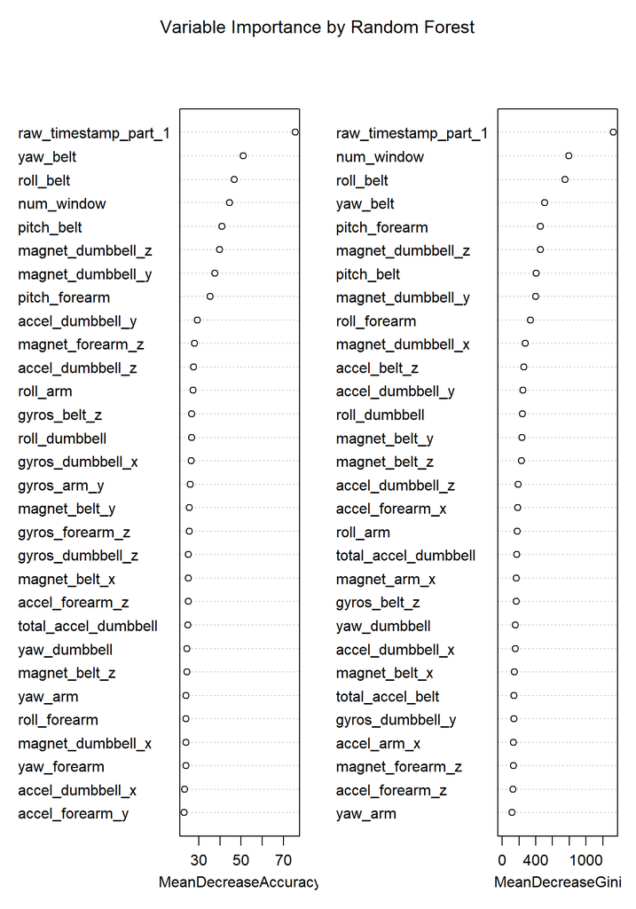

```r
# Plot the Random Forest Variable Importance
varImpPlot(fit_rf,main="Variable Importance by Random Forest")
```

```r
print(fit_rf)
```

```
##
## Call:
##  randomForest(formula = classe ~ ., data = Train_Use_mod, importance = TRUE,      ntree = 500)
##                Type of random forest: classification
##                      Number of trees: 500
## No. of variables tried at each split: 7
##
##         OOB estimate of  error rate: 0.13%
## Confusion matrix:
##      A    B    C    D    E  class.error
## A 3906    0    0    0    0 0.0000000000
## B    2 2655    1    0    0 0.0011286682
## C    0    4 2391    1    0 0.0020868114
## D    0    0    6 2244    2 0.0035523979
## E    0    0    0    2 2523 0.0007920792
```

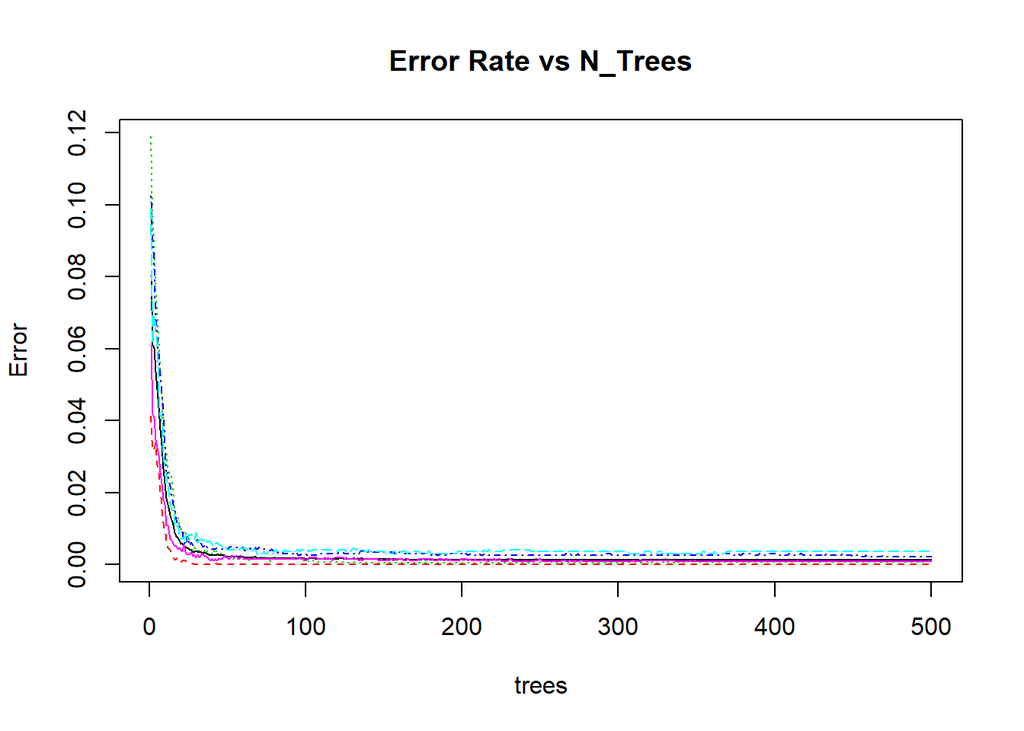

```r
plot(fit_rf,main="Error Rate vs N_Trees")
```

### Validation

```r
predict_test <- predict(fit_rf, Test_Use, type = "class")
confusionMatrix(Test_Use$classe, predict_test)
```

```
## Confusion Matrix and Statistics
##
##           Reference
## Prediction    A    B    C    D    E
##          A 1674    0    0    0    0
##          B    2 1136    1    0    0
##          C    0    2 1024    0    0
##          D    0    0    5  959    0
##          E    0    0    0    0 1082
##
## Overall Statistics
##
##                Accuracy : 0.9983
##                  95% CI : (0.9969, 0.9992)
##     No Information Rate : 0.2848
##     P-Value [Acc > NIR] : < 2.2e-16
##
##                   Kappa : 0.9979
##  Mcnemar's Test P-Value : NA
##
## Statistics by Class:
##
##                      Class: A Class: B Class: C Class: D Class: E
## Sensitivity            0.9988   0.9982   0.9942   1.0000   1.0000
## Specificity            1.0000   0.9994   0.9996   0.9990   1.0000
## Pos Pred Value         1.0000   0.9974   0.9981   0.9948   1.0000
## Neg Pred Value         0.9995   0.9996   0.9988   1.0000   1.0000
## Prevalence             0.2848   0.1934   0.1750   0.1630   0.1839
## Detection Rate         0.2845   0.1930   0.1740   0.1630   0.1839
## Detection Prevalence   0.2845   0.1935   0.1743   0.1638   0.1839
## Balanced Accuracy      0.9994   0.9988   0.9969   0.9995   1.0000
```

The Overall Accuracy rate is 0.9983. The in-traning and testing validation illustrate that the random forest method is stable across different samples, which leads to high accuracy for this problem. Then we will perform final testing on the dataset.

### Final Prediction

```r
orig_predict_test <- predict(fit_rf, Test_data, type = "class")
orig_predict_test
```

```
##  1  2  3  4  5  6  7  8  9 10 11 12 13 14 15 16 17 18 19 20
##  B  A  B  A  A  E  D  B  A  A  B  C  B  A  E  E  A  B  B  B
## Levels: A B C D E
```